# Identifying parameters for clustering the CRC v1 dataset

Data Lab for ALSF

2026

The goal of this notebook is to identify appropriate parameters to use to cluster (using expression values only) the CRC dataset. We will use the Leiden algorithm with the modularity objective function and Jaccard weighting for all clusters. But, we’ll explore different values for `k` (nearest neighbors) as well as `resolution` using metrics silhouette width, neighborhood purity, and stability with ARI.

# Setup and import

```r
suppressPackageStartupMessages({
  library(SpatialExperiment)
  library(ggplot2)
})

# set theme for ggplot2 plots
theme_set(theme_bw())
```

First, we’ll set a random seed and read in the data.

```r
set.seed(2026)
```

```r
data_dir <- here::here("data/crc-v1/normalized")
crc_rds <- file.path(data_dir, "crc_normalized_spe.rds")
```

```r
spe <- readRDS(crc_rds)
```

# Calculate clusters across parameter values

We’ll build a grid that combines a range of resolution values with a range of nearest-neighbor values, so we can see how both parameters jointly affect clustering.

```r
res_params <- seq(0.25, 1.5, 0.25)
k_params <- seq(5, 30, 5)

# combine into a grid of all resolution/k combinations
param_grid <- tidyr::expand_grid(
  res_param = res_params,
  k_param = k_params
) |>
  dplyr::mutate(combo = glue::glue("res{res_param}_k{k_param}"))
```

Next, we’ll calculate the PCA matrix we’ll use for clustering, considering only the top 2000 highly-variable genes.

```r
gene_variance <- scran::modelGeneVar(spe)
hv_genes <- scran::getTopHVGs(gene_variance, n = 2000)
spe <- scater::runPCA(spe, subset_row = hv_genes)
```

We’ll calculate clusters over the grid of parameter combinations, using Leiden with modularity objective function and Jaccard weighting.

```r
cluster_list <- param_grid |>
  # Perform clustering for each resolution/k combination
  purrr::pmap(
    \(res_param, k_param, combo) {

      cluster_params <- bluster::NNGraphParam(
        k = k_param,
        type = "jaccard",
        cluster.fun = "leiden",
        cluster.args = list(
          objective_function = "modularity",
          resolution = res_param
        )
      )

      scran::clusterCells(
        spe,
        use.dimred = "PCA",
        BLUSPARAM = cluster_params
      )
    }
  ) |>
  purrr::set_names(param_grid$combo)
```

How many clusters are in each combination of parameter values? Note that random seed state used for each calculation here will not precisely correspond to the exercise notebook itself, so this number of clusters applies primarily to this exploration.

```r
param_grid |>
  dplyr::mutate(
    n_clusters = purrr::map_int(cluster_list, \(x) length(levels(x)))
  ) |>
  tidyr::pivot_wider(
    id_cols = res_param,
    names_from = k_param,
    values_from = n_clusters,
    names_prefix = "k"
  )
```

| res_param | k5 | k10 | k15 | k20 | k25 | k30 |
| --- | --- | --- | --- | --- | --- | --- |
| 0.25 | 7 | 4 | 5 | 3 | 3 | 3 |
| 0.50 | 11 | 8 | 7 | 6 | 6 | 7 |
| 0.75 | 17 | 11 | 10 | 9 | 8 | 8 |
| 1.00 | 18 | 14 | 12 | 11 | 9 | 10 |
| 1.25 | 23 | 16 | 14 | 14 | 14 | 11 |
| 1.50 | 25 | 18 | 16 | 15 | 14 | 13 |

Next, we’ll evaluate these clusters using several metrics.

# Evaluate clusters

## Silhouette width

Silhouette width is commonly used to measure how well separated clusters are. For each spot, we compare the average distance to other spots in the same cluster to the average distance to spots in different clusters. *Note*: When we say “distance” here, we are referring to the nearest-neighbor graph used to build clusters, *not* physical distance in the tissue section. This value ranges from -1 to 1. Spots in well-separated clusters should have high silhouette values closer to 1. You can read more about silhouette width purity from the [*Orchestrating Single Cell Analysis with Bioconductor* book](https://bioconductor.org/books/3.22/OSCA.advanced/clustering-redux.html#silhouette-width). It’s worth noting that due to the high complexity of transcriptomic data, it’s very rare to see silhouette values that are actually close to 1; we’ll interpret results here as “higher is better.”

```r
cluster_silhouette_df <- cluster_list |>
  purrr::map(
    \(clusters) {
      bluster::approxSilhouette(
        reducedDim(spe, "PCA"),
        clusters
      ) |>
        # coerce to data frame
        as.data.frame() |>
        # store barcodes as a column, not row names
        tibble::rownames_to_column(var = "barcode")
    }
  ) |>
  # combine all data frames into one, storing the combo label for each in a new column
  purrr::list_rbind(names_to = "combo") |>
  # split the combo label back out into resolution and k columns
  tidyr::separate(combo, into = c("resolution", "k"), sep = "_") |>
  dplyr::mutate(
    resolution = stringr::str_remove(resolution, "^res") |> as.numeric() |> as.factor(),
    k = stringr::str_remove(k, "^k") |> as.numeric() |> as.factor()
  )
```

```
No summary function supplied, defaulting to `mean_se()`
```

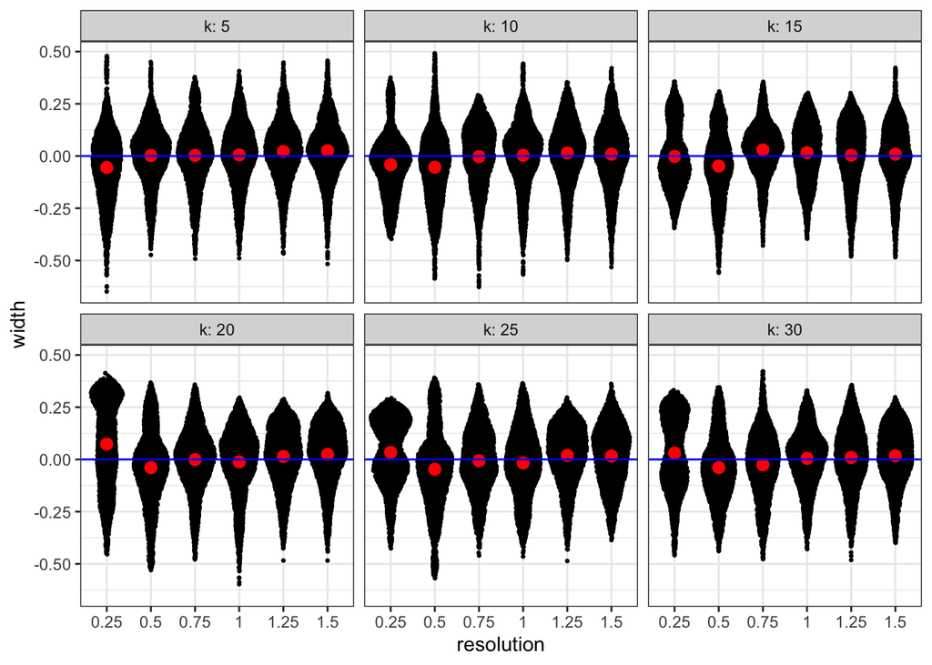

```r
# Plot violin plot of silhouette width across resolution values, faceted by k
ggplot(cluster_silhouette_df) +
  aes(x = resolution, y = width) +
  ggforce::geom_sina(size = 0.5) +
  stat_summary(color = "red") +
  geom_hline(color = "blue", yintercept = 0) +
  facet_wrap(vars(k), labeller = label_both)
```

The blue line above is at 0, which represents the middle of the silhouette width scale.

## Neighborhood purity

Neighborhood purity is a single metric per spot defined as the proportion of neighboring spots that are assigned to the same cluster. Neighborhood purity ranges from 0 to 1. Spots in well-separated clusters should have high purity values closer to 1, since there should be minimal overlap between member and neighboring spots. You can read more about neighborhood purity from the [*Orchestrating Single Cell Analysis with Bioconductor* book](https://bioconductor.org/books/3.22/OSCA.advanced/clustering-redux.html#cluster-purity).

As with silhouette width, neighborhood purity values will tend to be higher when there are very few clusters - when there aren’t many clusters, it’s much more likely that neighboring cells will be in the same cluster as one another, regardless of whether the clustering itself is optimal.

```r
# Calculate neighborhood purity for each set of clusters
cluster_purity_df <- cluster_list |>
  purrr::map(
    \(clusters) {
      bluster::neighborPurity(
        reducedDim(spe, "PCA"),
        clusters
      ) |>
      as.data.frame() |>
      tibble::rownames_to_column(var = "barcode") |>
      dplyr::mutate(cluster = clusters)
    }
  ) |>
  purrr::list_rbind(names_to = "combo") |>
  tidyr::separate(combo, into = c("resolution", "k"), sep = "_") |>
  dplyr::mutate(
    resolution = stringr::str_remove(resolution, "^res") |> as.numeric() |> as.factor(),
    k = stringr::str_remove(k, "^k") |> as.numeric() |> as.factor()
  )
```

```
No summary function supplied, defaulting to `mean_se()`
```

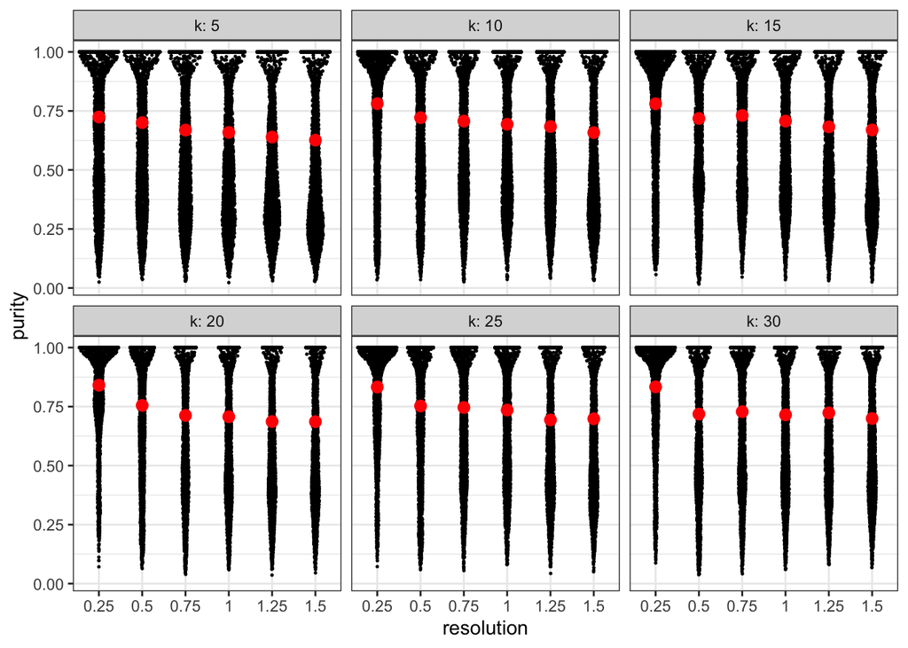

```r
# Plot boxplots of purity across resolution values, faceted by k
ggplot(cluster_purity_df) +
  aes(x = resolution, y = purity) +
  ggforce::geom_sina(size = 0.25) +
  stat_summary(color = "red") +
  facet_wrap(vars(k), labeller = label_both)
```

## Stability

The last metric we’ll assess is stability which uses a bootstrapping procedure:

- Sample PCA rows (aka, spots) with replacement to create a bootstrapped PCA matrix
- Perform clustering on this bootstrapped PCA matrix
- Compare the bootstrapped clusters to the original ones using (here) a metric called Adjusted Rand Index (ARI)

ARI asks whether spots grouped together in one clustering (here, the original clusters) are still grouped together in a different clustering (here, a set of bootstrapped clusters). ARI itself is the proportion of pairs of spots which have the same status (e.g., clustered together or separately) in both clusterings being compared. ARI ranges from -1 to 1, where:

- A value of 1 indicates clusterings are completely overlapping
- A value of -1 indicates clusterings are completely distinct
- A value of 0 indicates a random relationship

Therefore, if clusters are stable, we expect that spots clustered together in the original clusters are also grouped together in the bootstrapped clusters and ARI values are high across bootstrap replicates.

```r
stability_index <- purrr::pmap(
  param_grid,
  \(res_param, k_param, combo) {
    clusters <- cluster_list[[combo]]

    # First, define the clustering parameters
    cluster_params <- bluster::NNGraphParam(
      k = k_param,
      type = "jaccard",
      cluster.fun = "leiden",
      cluster.args = list(
        objective_function = "modularity",
        # Make sure the resolution value we pass in is numeric!
        resolution = as.numeric(res_param)
      )
    )

    # Perform bootstrapping and calculate stability with 100 bootstrap replicates
    # We use this purrr::map() approach to get a full distribution and plot each replicate individually
    # This has a longer runtime than running all 100 at once, but provides more insight
    values <- purrr::map_dbl(1:100, \(x) {
        bluster::bootstrapStability(
          reducedDim(spe, "PCA"),
          clusters = clusters,
          BLUSPARAM = cluster_params,
          iterations = 1,
          mode = "index"
        )}
      )
    values
  }
) |>
  purrr::set_names(param_grid$combo)
```

```
No summary function supplied, defaulting to `mean_se()`
```

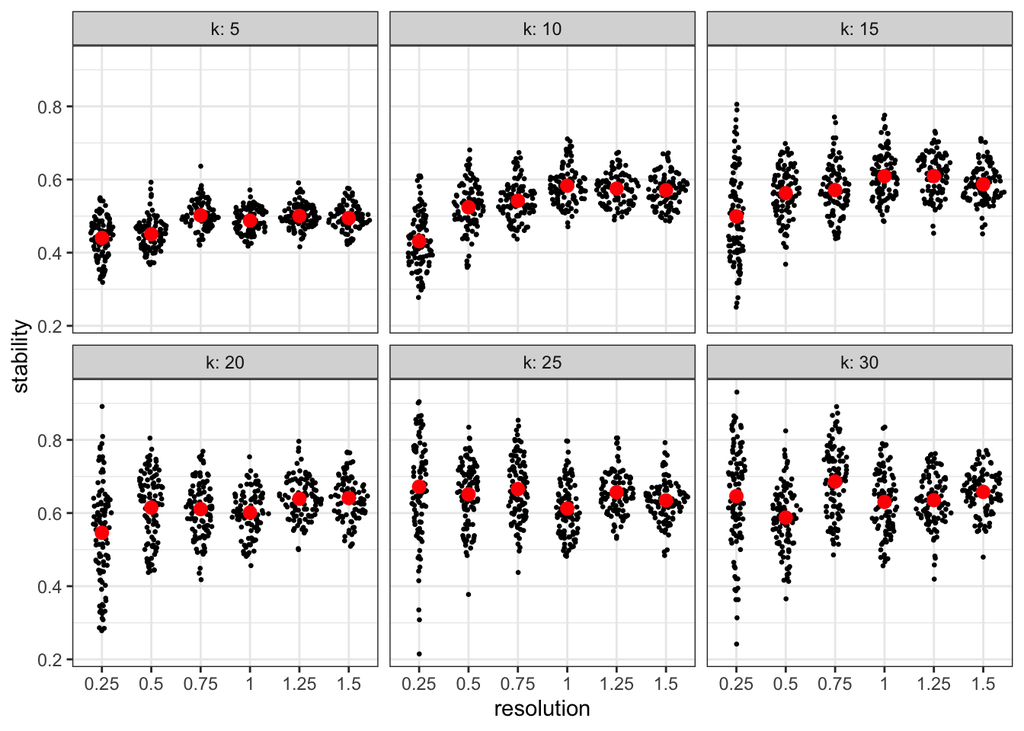

```r
stability_df <- stability_index |>
  as.data.frame() |>
  tidyr::pivot_longer(
    everything(),
    names_to = "combo",
    values_to = "stability"
  ) |>
  tidyr::separate(combo, into = c("resolution", "k"), sep = "_") |>
  dplyr::mutate(
    resolution = stringr::str_remove(resolution, "^res") |> as.numeric() |> as.factor(),
    k = stringr::str_remove(k, "^k") |> as.numeric() |> as.factor()
  )


ggplot(stability_df) +
  aes(x = resolution, y = stability) +
  ggforce::geom_sina(size = 0.5) +
  stat_summary(color = "red") +
  facet_wrap(vars(k), labeller = label_both)
```

# Conclusions

Considering all metrics, the parameters `resolution = 0.75` and `k = 25` seems reasonable to proceed with.

To conclude, we’ll visualize these clusters. Again, given differences in random seed state, these clusters may not precisely match those that will be calculated in the workshop.

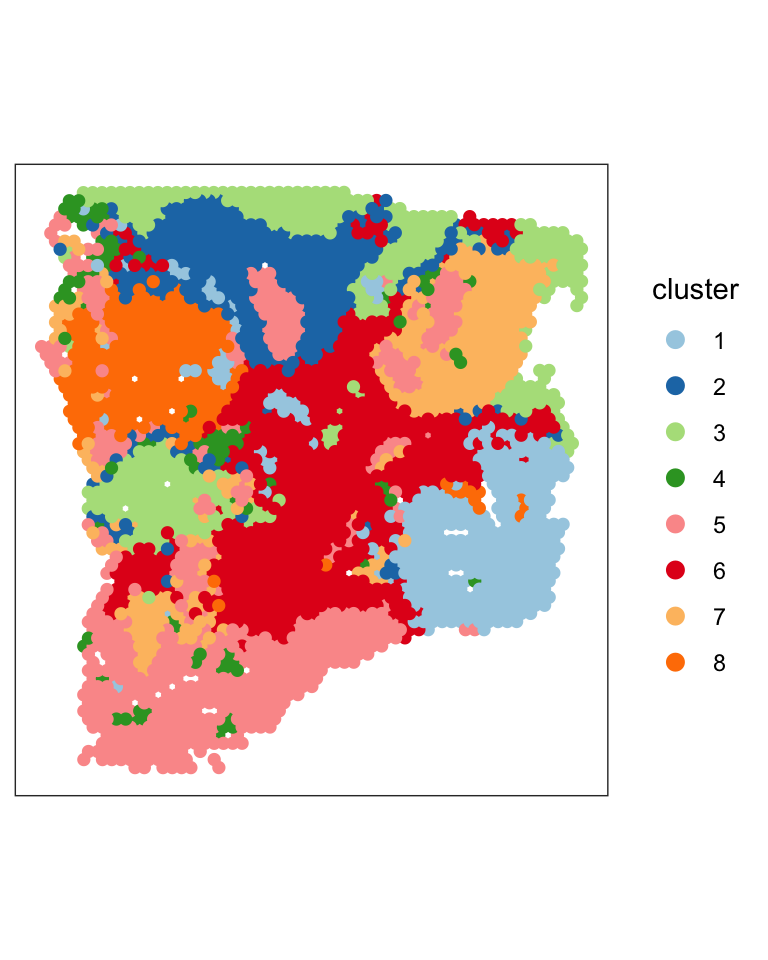

```r
spe$cluster <- cluster_list$res0.75_k25
ggspavis::plotCoords(
  spe,
  annotate = "cluster",
  point_size = 2
) +
  scale_color_brewer(palette = "Paired")
```